# Análisis de Correlación Lineal — Ejercicios

Claret Rodriguez Jimenez y Mariana Mendez

25 de November de 2025

# Instrucciones Generales

Para cada ejercicio, determine si existe evidencia suficiente para concluir que existe una correlación lineal entre las variables presentadas. Utilice diagramas de dispersión y calcule el coeficiente de correlación cuando sea necesario.

# Ejercicio 18-Tamaño de casinos e ingresos

A continuación se presentan los tamaños (en miles de pies cuadrados) y los ingresos (en millones de dólares) de casinos de Atlantic City (según datos del New York Times). ¿Existe evidencia suficiente para concluir que existe una correlación lineal entre el tamaño de los casinos y sus ingresos?

**Datos:** tamaños (miles de ft²) y ganancias (millones de USD).

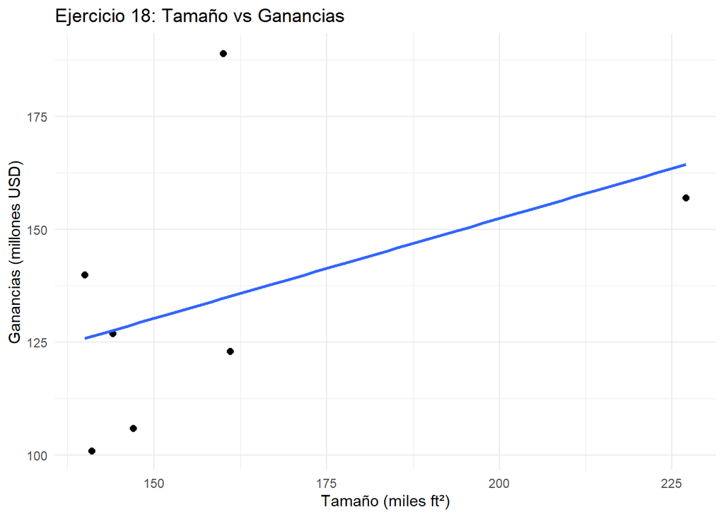

```r
# Datos
tamano <- c(160, 227, 140, 144, 161, 147, 141)
ganancias <- c(189, 157, 140, 127, 123, 106, 101)

df18 <- data.frame(tamano, ganancias)

# Gráfico
p18 <- ggplot(df18, aes(x = tamano, y = ganancias)) +
  geom_point(size=2) +
  geom_smooth(method = "lm", se = FALSE) +
  labs(title = "Ejercicio 18: Tamaño vs Ganancias",
       x = "Tamaño (miles ft²)", y = "Ganancias (millones USD)") +
  theme_minimal()

print(p18)
```

```r
# Correlación y prueba
r18 <- cor(df18$tamano, df18$ganancias, method = "pearson")
test18 <- cor.test(df18$tamano, df18$ganancias, method = "pearson")

r18
```

```
## [1] 0.444569
```

```r
test18
```

```
##
##  Pearson's product-moment correlation
##
## data:  df18$tamano and df18$ganancias
## t = 1.1098, df = 5, p-value = 0.3176
## alternative hypothesis: true correlation is not equal to 0
## 95 percent confidence interval:
##  -0.4637444  0.8972426
## sample estimates:
##      cor
## 0.444569
```

**Interpretación**

- Revisar el valor de `r` y el p-valor (`test18$p.value`). Si p < 0.05, hay evidencia de correlación lineal. Describir la dirección (positiva/negativa) y fuerza.

# Ejercicio 19-Tarifas aéreas

A continuación se presentan los precios (en dólares) de tarifas aéreas de diferentes aerolíneas desde la ciudad de Nueva York (JFK) a San Francisco. Los precios se basan en boletos comprados con 30 días de anticipación y un día de anticipación; las aerolíneas son US Air, Continental, Delta, United, American, Alaska y Northwest. ¿Hay evidencia suficiente para concluir que existe una correlación lineal entre los precios de los boletos comprados con 30 días de anticipación y los boletos comprados con un día de anticipación?

**Datos:** precios con 30 días y 1 día de anticipación (USD).

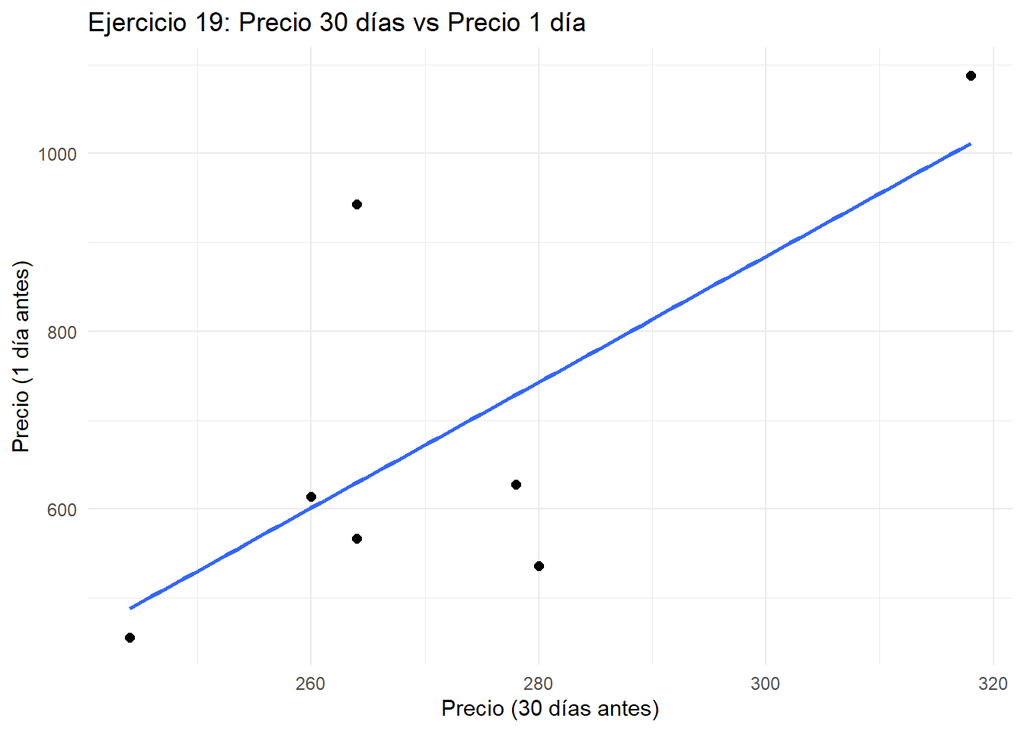

```r
# Datos
precio_30 <- c(244, 260, 264, 264, 278, 318, 280)
precio_1  <- c(456, 614, 567, 943, 628, 1088, 536)

df19 <- data.frame(precio_30, precio_1)

# Gráfico
p19 <- ggplot(df19, aes(x = precio_30, y = precio_1)) +
  geom_point(size=2) +
  geom_smooth(method = "lm", se = FALSE) +
  labs(title = "Ejercicio 19: Precio 30 días vs Precio 1 día",
       x = "Precio (30 días antes)", y = "Precio (1 día antes)") +
  theme_minimal()
print(p19)
```

```r
# Correlación y prueba
r19 <- cor(df19$precio_30, df19$precio_1, method = "pearson")
test19 <- cor.test(df19$precio_30, df19$precio_1, method = "pearson")

r19
```

```
## [1] 0.7087568
```

```r
test19
```

```
##
##  Pearson's product-moment correlation
##
## data:  df19$precio_30 and df19$precio_1
## t = 2.2465, df = 5, p-value = 0.0746
## alternative hypothesis: true correlation is not equal to 0
## 95 percent confidence interval:
##  -0.09501321  0.95310784
## sample estimates:
##       cor
## 0.7087568
```

**Interpretación**

- Si existen valores extremos (por ejemplo 943 o 1088), considerar comentar su influencia y, si corresponde, calcular correlación de Spearman como robusta a outliers.

```r
# Correlación de Spearman por si hay outliers
rs19 <- cor(df19$precio_30, df19$precio_1, method = "spearman")
rs19
```

```
## [1] 0.5225437
```

```r
cor.test(df19$precio_30, df19$precio_1, method = "spearman")
```

```
##
##  Spearman's rank correlation rho
##
## data:  df19$precio_30 and df19$precio_1
## S = 26.738, p-value = 0.2289
## alternative hypothesis: true rho is not equal to 0
## sample estimates:
##       rho
## 0.5225437
```

# Ejercicio 20-Pasajeros y espacios de estacionamiento

A continuación se presentan los números de pasajeros y los números de espacios de estacionamiento en diferentes estaciones del tren Metro-North (según datos de Metro- North). ¿Existe una correlación lineal entre los números de pasajeros y los números de espacios de estacionamiento?

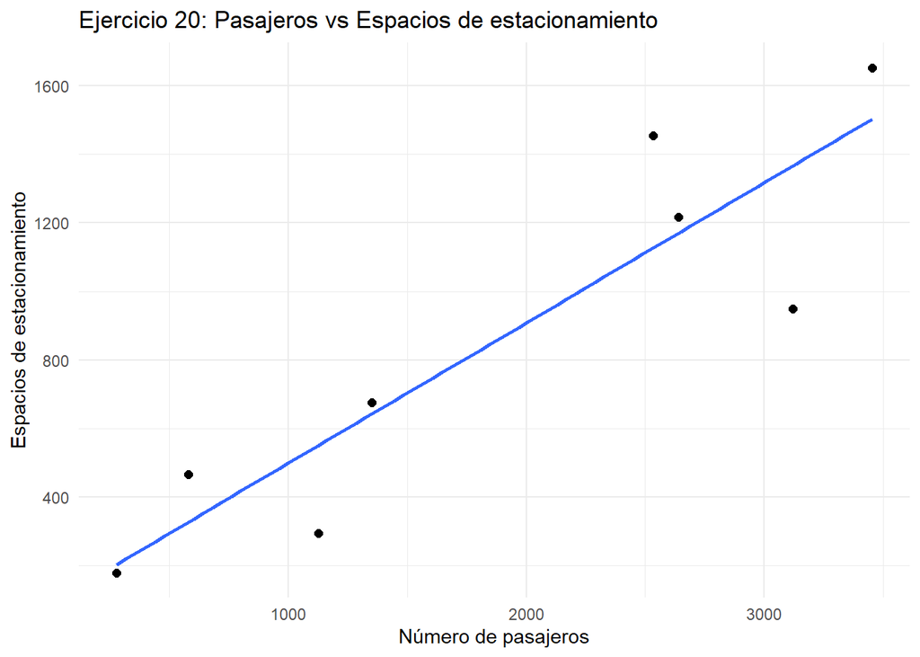

```r
# Datos
pasajeros <- c(3453, 1350, 1126, 3120, 2641, 277, 579, 2532)
espacios   <- c(1653, 676, 294, 950, 1216, 179, 466, 1454)

df20 <- data.frame(pasajeros, espacios)

p20 <- ggplot(df20, aes(x = pasajeros, y = espacios)) +
  geom_point(size=2) +
  geom_smooth(method = "lm", se = FALSE) +
  labs(title = "Ejercicio 20: Pasajeros vs Espacios de estacionamiento",
       x = "Número de pasajeros", y = "Espacios de estacionamiento") +
  theme_minimal()
print(p20)
```

```r
r20 <- cor(df20$pasajeros, df20$espacios, method = "pearson")
test20 <- cor.test(df20$pasajeros, df20$espacios, method = "pearson")

r20
```

```
## [1] 0.9011516
```

```r
test20
```

```
##
##  Pearson's product-moment correlation
##
## data:  df20$pasajeros and df20$espacios
## t = 5.0919, df = 6, p-value = 0.002239
## alternative hypothesis: true correlation is not equal to 0
## 95 percent confidence interval:
##  0.5383229 0.9821454
## sample estimates:
##       cor
## 0.9011516
```

# Ejercicio 21-Costos de reparación (choques frontales y traseros)

A continuación se presentan los costos de reparación (en dólares) para automóviles que participaron en pruebas de choques frontales a una velocidad de 6 mi/h y en pruebas de choques traseros a una velocidad de 6 mi/h (según datos del Insurance Institute for Highway Safety). Los automóviles son Toyota Camry, Mazda 6, Volvo S40, Saturn Aura, Subaru Legacy, Hyundai Sonata y Honda Accord. ¿Hay evidencia suficiente para concluir que existe una correlación lineal entre los costos de reparación de los choques frontales y de los choques traseros?

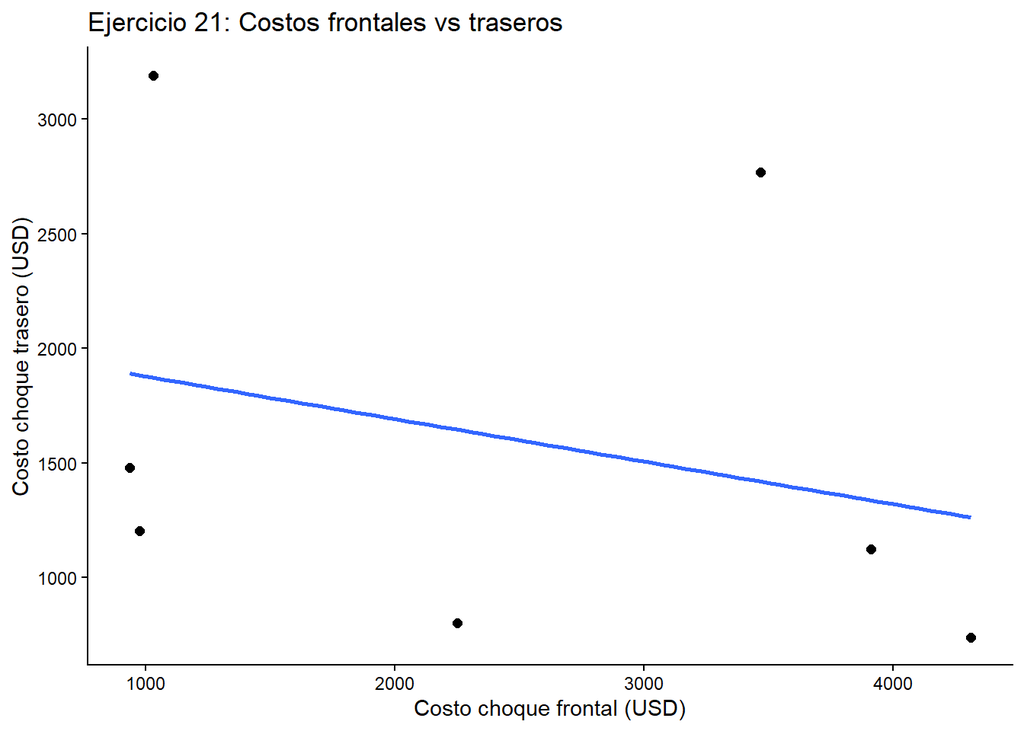

```r
# Datos
frontales <- c(936, 978, 2252, 1032, 3911, 4312, 3469)
traseros  <- c(1480, 1202, 802, 3191, 1122, 739, 2767)

df21 <- data.frame(frontales, traseros)

p21 <- ggplot(df21, aes(x = frontales, y = traseros)) +
  geom_point(size=2) +
  geom_smooth(method = "lm", se = FALSE) +
  labs(title = "Ejercicio 21: Costos frontales vs traseros",
       x = "Costo choque frontal (USD)", y = "Costo choque trasero (USD)") +
  theme_classic()
print(p21)
```

```r
r21 <- cor(df21$frontales, df21$traseros, method = "pearson")
test21 <- cor.test(df21$frontales, df21$traseros, method = "pearson")

r21
```

```
## [1] -0.2825546
```

```r
test21
```

```
##
##  Pearson's product-moment correlation
##
## data:  df21$frontales and df21$traseros
## t = -0.65865, df = 5, p-value = 0.5392
## alternative hypothesis: true correlation is not equal to 0
## 95 percent confidence interval:
##  -0.8539163  0.5976773
## sample estimates:
##        cor
## -0.2825546
```